# Определение рыночной стоимости объектов недвижимости, типичных параметров квартир, зависимости цены от удаленности от центра города

**Цель проекта:** научиться определять рыночную стоимость объектов недвижимости.

**Задача проекта:** установить параметры, которые влияют на рыночную стоимость объектов недвижимости.  
Результаты выполнения проекта позволят отслеживать аномалии и мошенническую деятельность в обЪявлениях о продаже квартир.

**Исходные данные** — это данные сервиса Яндекс.Недвижимость: архив объявлений о продаже квартир в Санкт-Петербурге и соседних населённых пунктов за несколько лет.

# 1. Изучение данных.

```python
import pandas as pd
import matplotlib.pyplot as plt
import seaborn as sns
sns.set_style("darkgrid")
from IPython.display import display
```

```python
# в dataset применен разделитель "\t" а не запятые
df = pd.read_csv("C:\\Users\\user\\Desktop\\Projects\\3\\real_estate_data.csv", sep='\t')
display(df.head(100)) # посмотрим на пример заполнения строк данных
```

|  | total_images | last_price | total_area | first_day_exposition | rooms | ceiling_height | floors_total | living_area | floor | is_apartment | ... | kitchen_area | balcony | locality_name | airports_nearest | cityCenters_nearest | parks_around3000 | parks_nearest | ponds_around3000 | ponds_nearest | days_exposition |
| --- | --- | --- | --- | --- | --- | --- | --- | --- | --- | --- | --- | --- | --- | --- | --- | --- | --- | --- | --- | --- | --- |
| 0 | 20 | 13000000.0 | 108.0 | 2019-03-07T00:00:00 | 3 | 2.70 | 16.0 | 51.0 | 8 | NaN | ... | 25.0 | NaN | Санкт-Петербург | 18863.0 | 16028.0 | 1.0 | 482.0 | 2.0 | 755.0 | NaN |
| 1 | 7 | 3350000.0 | 40.4 | 2018-12-04T00:00:00 | 1 | NaN | 11.0 | 18.6 | 1 | NaN | ... | 11.0 | 2.0 | посёлок Шушары | 12817.0 | 18603.0 | 0.0 | NaN | 0.0 | NaN | 81.0 |
| 2 | 10 | 5196000.0 | 56.0 | 2015-08-20T00:00:00 | 2 | NaN | 5.0 | 34.3 | 4 | NaN | ... | 8.3 | 0.0 | Санкт-Петербург | 21741.0 | 13933.0 | 1.0 | 90.0 | 2.0 | 574.0 | 558.0 |
| 3 | 0 | 64900000.0 | 159.0 | 2015-07-24T00:00:00 | 3 | NaN | 14.0 | NaN | 9 | NaN | ... | NaN | 0.0 | Санкт-Петербург | 28098.0 | 6800.0 | 2.0 | 84.0 | 3.0 | 234.0 | 424.0 |
| 4 | 2 | 10000000.0 | 100.0 | 2018-06-19T00:00:00 | 2 | 3.03 | 14.0 | 32.0 | 13 | NaN | ... | 41.0 | NaN | Санкт-Петербург | 31856.0 | 8098.0 | 2.0 | 112.0 | 1.0 | 48.0 | 121.0 |
| ... | ... | ... | ... | ... | ... | ... | ... | ... | ... | ... | ... | ... | ... | ... | ... | ... | ... | ... | ... | ... | ... |
| 95 | 14 | 5150000.0 | 47.0 | 2018-08-06T00:00:00 | 2 | 2.75 | 9.0 | 28.1 | 9 | False | ... | 7.0 | 2.0 | Санкт-Петербург | 10142.0 | 13743.0 | 2.0 | 751.0 | 1.0 | 881.0 | 34.0 |
| 96 | 20 | 8780000.0 | 78.3 | 2018-08-24T00:00:00 | 3 | 2.50 | 15.0 | 51.0 | 9 | NaN | ... | 11.0 | NaN | Санкт-Петербург | 52108.0 | 16333.0 | 0.0 | NaN | 1.0 | 746.0 | 31.0 |
| 97 | 15 | 4898000.0 | 146.0 | 2019-02-12T00:00:00 | 4 | NaN | 2.0 | 77.0 | 2 | NaN | ... | 13.0 | NaN | Выборг | NaN | NaN | NaN | NaN | NaN | NaN | 34.0 |
| 98 | 11 | 11700000.0 | 80.0 | 2014-12-10T00:00:00 | 3 | NaN | 5.0 | 55.1 | 3 | NaN | ... | 11.0 | 0.0 | Санкт-Петербург | 11248.0 | 8767.0 | 1.0 | 666.0 | 0.0 | NaN | 831.0 |
| 99 | 32 | 9600000.0 | 90.0 | 2017-09-26T00:00:00 | 4 | NaN | 5.0 | 67.0 | 2 | NaN | ... | 8.0 | NaN | Санкт-Петербург | 23277.0 | 2818.0 | 0.0 | NaN | 0.0 | NaN | 104.0 |

100 rows × 22 columns

```python
print('Дубликатов:', df.duplicated().sum()) #Проверим наличие дубликатов строк
df.info() # изучим информацию о типах данных в столбцах и размере датафрейма, возможных пропусках в данных
df.describe() #попытаемся понять, есть ли аномальные значения
```

```
Дубликатов: 0
<class 'pandas.core.frame.DataFrame'>
RangeIndex: 23699 entries, 0 to 23698
Data columns (total 22 columns):
 #   Column                Non-Null Count  Dtype
---  ------                --------------  -----
 0   total_images          23699 non-null  int64
 1   last_price            23699 non-null  float64
 2   total_area            23699 non-null  float64
 3   first_day_exposition  23699 non-null  object
 4   rooms                 23699 non-null  int64
 5   ceiling_height        14504 non-null  float64
 6   floors_total          23613 non-null  float64
 7   living_area           21796 non-null  float64
 8   floor                 23699 non-null  int64
 9   is_apartment          2775 non-null   object
 10  studio                23699 non-null  bool
 11  open_plan             23699 non-null  bool
 12  kitchen_area          21421 non-null  float64
 13  balcony               12180 non-null  float64
 14  locality_name         23650 non-null  object
 15  airports_nearest      18157 non-null  float64
 16  cityCenters_nearest   18180 non-null  float64
 17  parks_around3000      18181 non-null  float64
 18  parks_nearest         8079 non-null   float64
 19  ponds_around3000      18181 non-null  float64
 20  ponds_nearest         9110 non-null   float64
 21  days_exposition       20518 non-null  float64
dtypes: bool(2), float64(14), int64(3), object(3)
memory usage: 3.7+ MB
```

|  | total_images | last_price | total_area | rooms | ceiling_height | floors_total | living_area | floor | kitchen_area | balcony | airports_nearest | cityCenters_nearest | parks_around3000 | parks_nearest | ponds_around3000 | ponds_nearest | days_exposition |
| --- | --- | --- | --- | --- | --- | --- | --- | --- | --- | --- | --- | --- | --- | --- | --- | --- | --- |
| count | 23699.000000 | 2.369900e+04 | 23699.000000 | 23699.000000 | 14504.000000 | 23613.000000 | 21796.000000 | 23699.000000 | 21421.000000 | 12180.000000 | 18157.000000 | 18180.000000 | 18181.000000 | 8079.000000 | 18181.000000 | 9110.000000 | 20518.000000 |
| mean | 9.858475 | 6.541549e+06 | 60.348651 | 2.070636 | 2.771499 | 10.673824 | 34.457852 | 5.892358 | 10.569807 | 1.150082 | 28793.672193 | 14191.277833 | 0.611408 | 490.804555 | 0.770255 | 517.980900 | 180.888634 |
| std | 5.682529 | 1.088701e+07 | 35.654083 | 1.078405 | 1.261056 | 6.597173 | 22.030445 | 4.885249 | 5.905438 | 1.071300 | 12630.880622 | 8608.386210 | 0.802074 | 342.317995 | 0.938346 | 277.720643 | 219.727988 |
| min | 0.000000 | 1.219000e+04 | 12.000000 | 0.000000 | 1.000000 | 1.000000 | 2.000000 | 1.000000 | 1.300000 | 0.000000 | 0.000000 | 181.000000 | 0.000000 | 1.000000 | 0.000000 | 13.000000 | 1.000000 |
| 25% | 6.000000 | 3.400000e+06 | 40.000000 | 1.000000 | 2.520000 | 5.000000 | 18.600000 | 2.000000 | 7.000000 | 0.000000 | 18585.000000 | 9238.000000 | 0.000000 | 288.000000 | 0.000000 | 294.000000 | 45.000000 |
| 50% | 9.000000 | 4.650000e+06 | 52.000000 | 2.000000 | 2.650000 | 9.000000 | 30.000000 | 4.000000 | 9.100000 | 1.000000 | 26726.000000 | 13098.500000 | 0.000000 | 455.000000 | 1.000000 | 502.000000 | 95.000000 |
| 75% | 14.000000 | 6.800000e+06 | 69.900000 | 3.000000 | 2.800000 | 16.000000 | 42.300000 | 8.000000 | 12.000000 | 2.000000 | 37273.000000 | 16293.000000 | 1.000000 | 612.000000 | 1.000000 | 729.000000 | 232.000000 |
| max | 50.000000 | 7.630000e+08 | 900.000000 | 19.000000 | 100.000000 | 60.000000 | 409.700000 | 33.000000 | 112.000000 | 5.000000 | 84869.000000 | 65968.000000 | 3.000000 | 3190.000000 | 3.000000 | 1344.000000 | 1580.000000 |

Количество строк в столбцах не совпадают, значит в данных есть пропуски.

Дубликаты строк не обнаружены

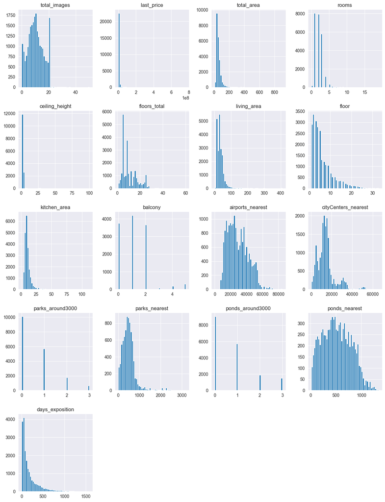

```python
df.hist(bins=50, figsize=(15, 20)); # строим общую гистограмму для всех числовых столбцов таблицы
```

**Подитог 1 по разделу об изучении данных:**

В таблице 23699 строк (обЪявлений).  
Дубликаты строк не обнаружены.

В таблице есть пропуски в столбцах: ceiling_height, floors_total, living_area, is_apartment, kitchen_area, balcony,  
locality_name, airports_nearest, cityCenters_nearest, parks_around3000, parks_nearest, ponds_around3000, ponds_nearest,  
days_exposition.  
Большая часть столбов имеет числовое значения (тип int или float).  
за ислючением:

```
- столбца **first_day_exposition** (обьектный тип c датой, который заменим на **datetime64** , чтобы можно было работать со значениями дат), а также
- столбцы studio, open_plan имеют булев тип, что правильно,
- столбец **is_apartment** скорее всего должен иметь **булев тип**, а не обьект.
```

**balcony, floors_total, last_price, parks_around3000, ponds_around3000** поменяем на тип **int**, т.к. данные значения предполагаются целочисленные.

Столбцы ceiling_height, living_area, kitchen_area имеют много пропущенных значений. days_exposition тоже поменяем на int, предварительно добавив флаг 0 для пропущенных значений.

Также переименуем столбец cityCenters_nearest в city_сenters_nearest.  
Ряд значений в столбцах имеют аномальные значения.

**Гистограммы распределения по параметрам таблицы:**

- Ненормально выглядит распределение по количеству фотографий, но на данное исследование этот параметр не влияет.
- По параметру last price видно, что есть сильно выбивающиеся значения, не относящиеся к основной массе данных, что очень сильно искажает картину распредления. Желательно рассматривать данные до 70 млн.руб.
- Тоже самое относится к параметру total area, но в чуть меньшей степени. Желательно рассматривать данные до 300 кв.м.
- По параметру ceiling_height значения вообще практически идентичны, что говорит о наличии сильных аномальных значений. Данные желательно получать не больше 10 м
- По параметрам floors_total, living_area есть две-три сильно выделяющиеся из общей массы группы, которые своими очень высокими пиками выбиваются из общей картины. Желательно рассматривать данные по floors_total до 30, living_area до 100 кв.м.
- По параметру kitchen_area распределение более-менее выглядит нормально, но было бы лучше рассмотреть эти данные без сильно выбивающихся значений (30 кв.м. и меньше).
  - По параметру cityCenters_nearest распредление выглядит очень странным. Есть три ярко выраженные отдельные группы (возможно зоны застройки: 0-25 км, 25-40 км, 45-55 км). Возможно внутри этого параметра надо рассматривать не меньше 3 отдельных, не связанных между собой групп, и внутри каждой из них распределение будет приближено к нормальному.
- По параметру days_exposition распределение более-менее выглядит нормально, но было бы лучше рассмотреть эти данные без сильно выбивающихся значений (700 дней и меньше).
- По остальным параметрам ярко выраженных замечаний нет.

### 2. Предобработка данных

получены данные о требующих обработки пропусках в столбцах: ceiling_height, floors_total, living_area, is_apartment, kitchen_area, balcony, locality_name, airports_nearest, cityCenters_nearest, parks_around3000, parks_nearest, ponds_around3000, ponds_nearest, days_exposition.

```python
display(df.isna().sum())
```

```
total_images                0
last_price                  0
total_area                  0
first_day_exposition        0
rooms                       0
ceiling_height           9195
floors_total               86
living_area              1903
floor                       0
is_apartment            20924
studio                      0
open_plan                   0
kitchen_area             2278
balcony                 11519
locality_name              49
airports_nearest         5542
cityCenters_nearest      5519
parks_around3000         5518
parks_nearest           15620
ponds_around3000         5518
ponds_nearest           14589
days_exposition          3181
dtype: int64
```

Рассмотрим распредление пропусков по годам, предварительно поменяв тип столбца с датой публикации на Datetime и добавив столбец с годом публикации обьявления:

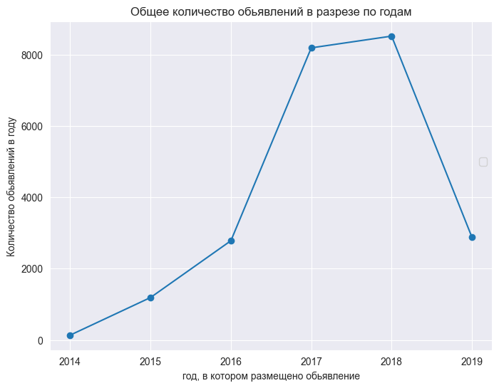

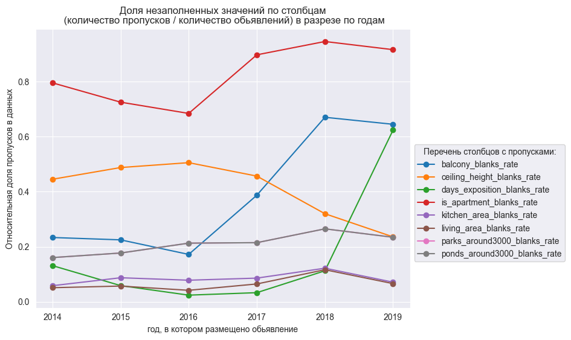

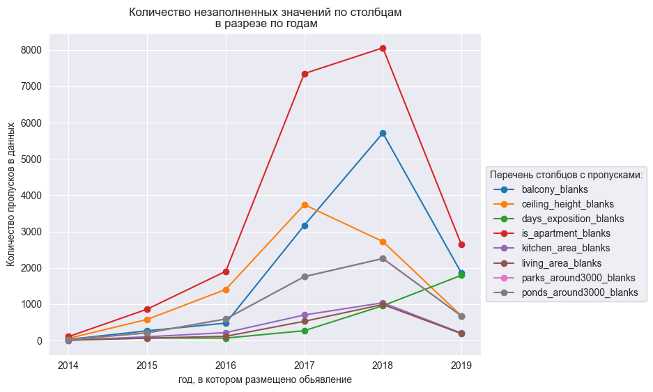

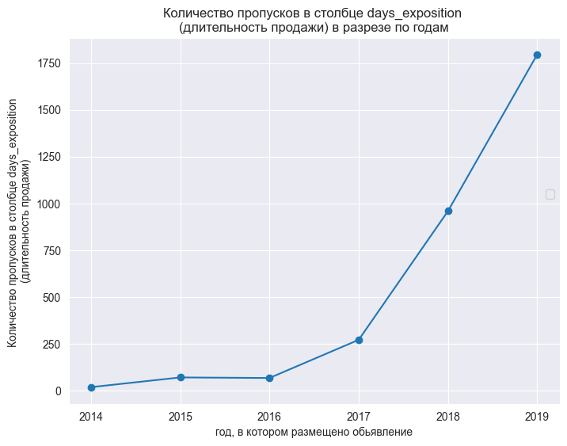

```python
#меняем тип столбца с датой публикации на Datetime
df['first_day_exposition'] = pd.to_datetime(df['first_day_exposition'], format='%Y-%m-%dT%H:%M:%S')

df['year'] = df['first_day_exposition'].dt.year #добавим столбец с годом размещения обьявления

#сравним долю пропущенных значений в общем количестве данных в разрезе по годам:
blanks = df.pivot_table(index='year', values=['days_exposition', 'balcony', 'parks_around3000', 'ponds_around3000', \
     'is_apartment', 'kitchen_area', 'living_area', 'ceiling_height'], aggfunc = 'count')
blanks['days_exposition_blanks'] = df[(df['days_exposition'].isna())]['year'].value_counts()
blanks['balcony_blanks'] = df[(df['balcony'].isna())]['year'].value_counts()
blanks['parks_around3000_blanks'] = df[(df['parks_around3000'].isna())]['year'].value_counts()
blanks['ponds_around3000_blanks'] = df[(df['ponds_around3000'].isna())]['year'].value_counts()
blanks['is_apartment_blanks'] = df[(df['is_apartment'].isna())]['year'].value_counts()
blanks['kitchen_area_blanks'] = df[(df['kitchen_area'].isna())]['year'].value_counts()
blanks['living_area_blanks'] = df[(df['living_area'].isna())]['year'].value_counts()
blanks['ceiling_height_blanks'] = df[(df['ceiling_height'].isna())]['year'].value_counts()
blanks['days_exposition_blanks_rate'] = blanks['days_exposition_blanks'] / (blanks['days_exposition'] + \
                                                                            blanks['days_exposition_blanks'])
blanks['balcony_blanks_rate'] = blanks['balcony_blanks'] / (blanks['balcony'] + blanks['balcony_blanks'])
blanks['parks_around3000_blanks_rate'] = blanks['parks_around3000_blanks'] / (blanks['parks_around3000'] + \
                                                                              blanks['parks_around3000_blanks'])
blanks['ponds_around3000_blanks_rate'] = blanks['ponds_around3000_blanks'] / (blanks['ponds_around3000'] + \
                                                                              blanks['ponds_around3000_blanks'])
blanks['is_apartment_blanks_rate'] = blanks['is_apartment_blanks'] / (blanks['is_apartment'] + blanks['is_apartment_blanks'])

blanks['kitchen_area_blanks_rate'] = blanks['kitchen_area_blanks'] / (blanks['kitchen_area'] + blanks['kitchen_area_blanks'])
blanks['living_area_blanks_rate'] = blanks['living_area_blanks'] / (blanks['living_area'] + blanks['living_area_blanks'])
blanks['ceiling_height_blanks_rate'] = blanks['ceiling_height_blanks'] / (blanks['ceiling_height'] + \
                                                                          blanks['ceiling_height_blanks'])


#визуализируем общее количество обьявлений в разрезе по годам:
df.pivot_table(index='year', values='first_day_exposition', aggfunc = 'count').plot(style='o-', figsize=(8, 6), sharex=False,\
                                                                                    grid=True)
plt.title('Общее количество обьявлений в разрезе по годам')
plt.xlabel('год, в котором размещено обьявление')
plt.ylabel('Количество обьявлений в году')
plt.legend('', bbox_to_anchor=(1, 0.6))
plt.show()

#визуализируем долю пропусков по столбцам в разрезе по годам:
blanks.pivot_table(index='year', values=['days_exposition_blanks_rate', 'balcony_blanks_rate', 'parks_around3000_blanks_rate',\
    'ponds_around3000_blanks_rate', 'is_apartment_blanks_rate', 'kitchen_area_blanks_rate', 'living_area_blanks_rate', \
    'ceiling_height_blanks_rate']).plot(style='o-', figsize=(8, 6), sharex=False, grid=True)
plt.title('Доля незаполненных значений по столбцам\n (количество пропусков / количество обьявлений) в разрезе по годам')
plt.xlabel('год, в котором размещено обьявление')
plt.ylabel('Относительная доля пропусков в данных')
plt.legend(bbox_to_anchor=(1, 0.6), title='Перечень столбцов с пропусками:')
plt.show()

#визуализируем количество пропусков по столбцам в разрезе по годам:
blanks.pivot_table(index='year', values=['days_exposition_blanks', 'balcony_blanks', 'parks_around3000_blanks',\
    'ponds_around3000_blanks', 'is_apartment_blanks', 'kitchen_area_blanks', 'living_area_blanks', \
    'ceiling_height_blanks']).plot(style='o-', figsize=(8, 6), sharex=False, grid=True)
plt.title('Количество незаполненных значений по столбцам\n в разрезе по годам')
plt.xlabel('год, в котором размещено обьявление')
plt.ylabel('Количество пропусков в данных')
plt.legend(bbox_to_anchor=(1, 0.6), title='Перечень столбцов с пропусками:')
plt.show()

##визуализируем количество пропусков в столбце days_exposition в разрезе по годам:
blanks['days_exposition_blanks'].plot(style='o-', figsize=(8, 6), sharex=False, grid=True)
plt.title('Количество пропусков в столбце days_exposition \n(длительность продажи) в разрезе по годам')
plt.xlabel('год, в котором размещено обьявление')
plt.ylabel('Количество пропусков в столбце days_exposition \n(длительность продажи)')
plt.legend('', bbox_to_anchor=(1, 0.6))
plt.show()
```

В период с 2014 по 2016 год количество обявлений росло, но доли пропусков в столбцах были относительно стабильны.